# Forest Fire Area Prediction

### not surprisingly, temp, RH, and DMC (Duff moisture code, so probably some kind of wetness) are the most important

### Time to adjust some parameters for the random forest

example for tuneRF from https://www.statology.org/random-forest-in-r/ model_tuned <- tuneRF( x=airquality[,-1], #define predictor variables y=airquality$Ozone, #define response variable ntreeTry=500, mtryStart=4, stepFactor=1.5, improve=0.01, trace=FALSE #don’t show real-time progress )

```r
ncol(trainingData)
```

```
## [1] 12
```

```r
str(trainingData)
```

```
## 'data.frame':    413 obs. of  12 variables:
##  $ X      : int  1 7 6 4 7 6 2 4 4 8 ...
##  $ Y      : int  5 4 5 3 4 3 2 4 4 6 ...
##  $ FFMC   : num  91 94.3 92.6 93.7 91.6 91.1 92.4 95.8 95.1 92.1 ...
##  $ DMC    : num  129.5 96.3 115.4 101.3 104.2 ...
##  $ DC     : num  693 200 777 423 475 ...
##  $ ISI    : num  7 56.1 8.8 14.7 9 7.1 12.2 13.8 17.7 8.2 ...
##  $ temp   : num  21.6 21 24.3 26.1 24.2 19.3 19.6 32.4 19.4 26.8 ...
##  $ RH     : int  33 44 27 45 32 39 33 21 71 35 ...
##  $ wind   : num  2.2 4.5 4.9 4 1.8 3.6 6.3 4.5 7.6 1.3 ...
##  $ rain   : num  0 0 0 0 0 0 0 0 0 0 ...
##  $ area   : num  11.53 0 0 7.36 0 ...
##  $ logArea: num  2.53 0 0 2.12 0 ...
```

```r
# we will want to use columns 1-10 for the tuneRF()

# tune it by messing with starting # of trees, identify best mtry and step
tunedForest <- tuneRF(
  x=trainingData[,1:10],
  y=trainingData$logArea,
  ntreeTry=500,
  #mtryStart = 1, #floor(sqrt(ncol(trainingData)-2)),# sqrt number of predictors
  stepFactor = 0.5,
  improve=0.01,
  trace=FALSE
)
```

```
## -0.007797907 0.01
## 0.0457422 0.01
```

```
## 0.002057467 0.01
```

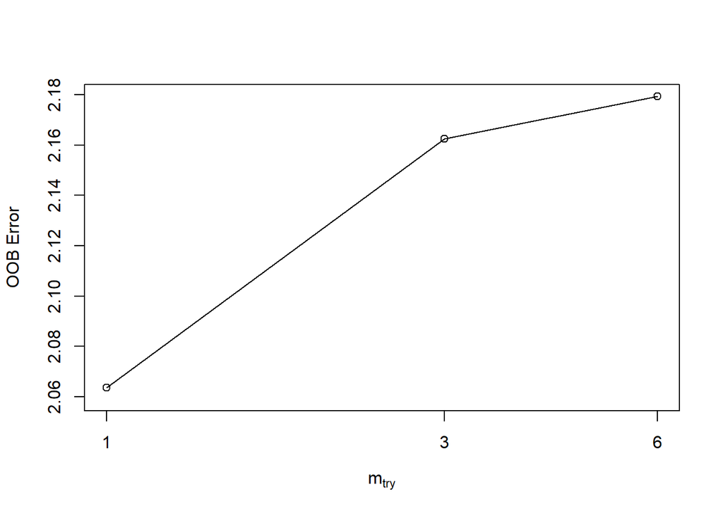

```r
# seems like a lower error with mtry=1
myTunedForest <- randomForest(data=trainingData,
                              logArea ~ .-area,
                              mtry=1)

# check it out
myTunedForest
```

```
##
## Call:
##  randomForest(formula = logArea ~ . - area, data = trainingData,      mtry = 1)
##                Type of random forest: regression
##                      Number of trees: 500
## No. of variables tried at each split: 1
##
##           Mean of squared residuals: 2.071028
##                     % Var explained: -4.76
```

```r
# best model?
which.min(myTunedForest$mse)
```

```
## [1] 220
```

```r
# RMSE of that model?
sqrt(myTunedForest$mse[which.min(myTunedForest$mse)])
```

```
## [1] 1.43542
```

### use that tuned model for predictions

```r
predictForest <- predict(myTunedForest, testData)

(myTunedForestRMSE <- myRMSE(predictForest, testData$logArea))
```

```
## [1] 1.357878
```

### TA-DA! A slight improvement in RMSE with this forest!

## Time for XGBoost!

```r
#install.packages("xgboost")
library(xgboost)
set.seed
```

[output not shown]

```r
# prepare train and test by building matrix objects that XGBoost expects
colnames(trainingData)
```

```
##  [1] "X"       "Y"       "FFMC"    "DMC"     "DC"      "ISI"     "temp"
##  [8] "RH"      "wind"    "rain"    "area"    "logArea"
```

```r
# want columns 1-10 as features and 12 as the label (outcome)
train_x <- data.matrix(trainingData[,1:10])
train_y <- trainingData[,12]

test_x <- data.matrix(testData[,1:10])
test_y <- testData[,12]

#define final training and testing sets
xgb_train = xgb.DMatrix(data = train_x, label = train_y)
xgb_test = xgb.DMatrix(data = test_x, label = test_y)

#define watchlist
watchlist = list(train=xgb_train, test=xgb_test)

#fit XGBoost model and display training and testing data at each round
model = xgb.train(data = xgb_train, max.depth = 3, watchlist=watchlist, nrounds = 50)
```

[output not shown]

### best model happened in round 2 with RMSE 1.335, an improvement! Let’s build that model and then we can later tweak some parameters.

```r
#define final model
final = xgb.train(data = xgb_train, max.depth = 3, nrounds = 2, verbose = 0)

# use it to predict and confirm RMSE
pred_xgb <- predict(final, test_x)

# get RMSE - same as above 1.3355
(myRMSE(pred_xgb, test_y))
```

```
## [1] 1.335529
```

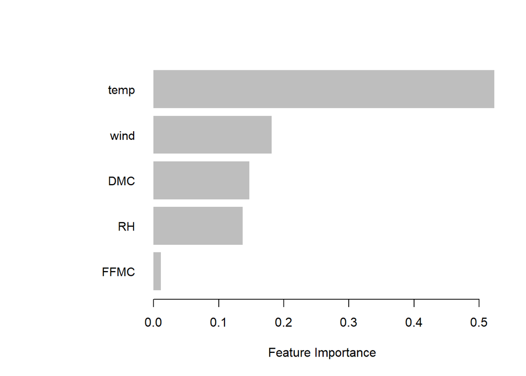

```r
# variable importance?
importance_matrix <- xgb.importance(model = final)
xgb.plot.importance(importance_matrix, xlab = "Feature Importance")
```

### we see that XGBoost has penalized several of the features (with its built in L1 and L2 regularization) so that the remaining best features are temperature, wind, DMC, RH, and FFMC

### let’s do a grid search to find the best parameters using the code from the r-bloggers post I referenced in class

```r
## Code from https://www.r-bloggers.com/2020/11/r-xgboost-regression/

#################
#grid search
#create hyperparameter grid
hyper_grid <- expand.grid(max_depth = seq(3, 6, 1),
                          eta = seq(.2, .35, .01))
xgb_train_rmse <- NULL
xgb_test_rmse <- NULL

for (j in 1:nrow(hyper_grid)) {
  set.seed(732)
  m_xgb_untuned <- xgb.cv(
    data = train_x,
    label = train_y,
    nrounds = 100,
    objective = "reg:squarederror",
    early_stopping_rounds = 3,
    nfold = 5,
    max_depth = hyper_grid$max_depth[j],
    eta = hyper_grid$eta[j]
  )

  xgb_train_rmse[j] <- m_xgb_untuned$evaluation_log$train_rmse_mean[m_xgb_untuned$best_iteration]
  xgb_test_rmse[j] <- m_xgb_untuned$evaluation_log$test_rmse_mean[m_xgb_untuned$best_iteration]

  cat(j, "\n")
}
```

[output not shown]

[output cut: 329 more lines]

[output not shown]

```r
#ideal hyperparamters
hyper_grid[which.min(xgb_test_rmse), ]
```

```
##    max_depth  eta
## 25         3 0.26
```

### OK, with those parameters, build that model and allow for more rounds

```r
#define final model
finalXGB = xgb.train(data = xgb_train,
                   max.depth = 3,
                   watchlist=watchlist,
                   eta=0.26,
                   nrounds = 400,
                   verbose = 1)
# round 3 is best testRMSE (1.330)
finalXGB = xgb.train(data = xgb_train,
                   max.depth = 3,
                   watchlist=watchlist,
                   eta=0.26,
                   nrounds = 3,
                   verbose = 0)

# use it to predict and confirm RMSE
pred_xgb <- predict(finalXGB, test_x)

# get RMSE - same as above 1.3355
(myRMSE(pred_xgb, test_y))
```

[output not shown]

```
## [1] 1.330407
```

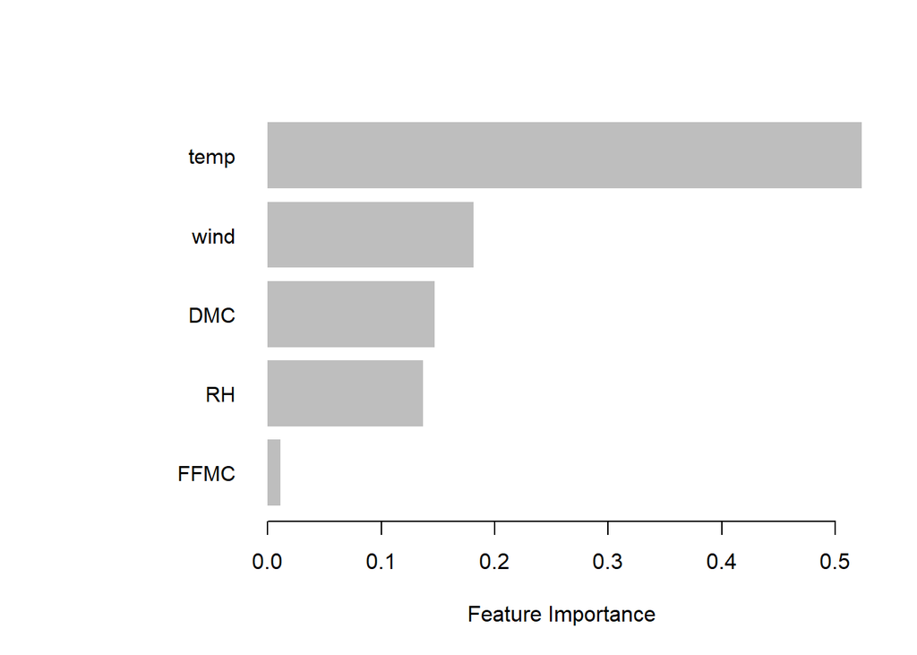

```r
# variable importance?
importance_matrix <- xgb.importance(model = final)
xgb.plot.importance(importance_matrix, xlab = "Feature Importance")
```

### Hooray, got an even better RMSE with that bit of tuning. Now have a model with a RMSE = 1.330